# Chapter 3. Basic reactivity

## 5.1 Timed invalidation

Imagine we want to constantly resimulating the data, so that we can see an animation rather than a static plot. We can increase the frequency of updates with a new function: `reactiveTimer()`.

**reactiveTimer() is a reactive expression that has a dependency on a hidden input: *the current time***. We use a `reactiveTimer()` when we want a reactive expression to invalidate itself more often. For example, the following code uses an interval of 500 ms, so that the plot will update twice a second.

```r
server <- function(input, output, session) {
  timer <- reactiveTimer(500)

  x1 <- reactive({
    timer()
    rpois(input$n, input$lambda1)
  })
  x2 <- reactive({
    timer()
    rpois(input$n, input$lambda2)
  })

  output$hist <- renderPlot({
    freqpoly(x1(), x2(), binwidth = 1, xlim = c(0, 40))
  })
}
```

To use `timer()` in the reactive expressions that compute `x1()` and `x2()`, we call it, but don’t use the value. This lets `x1` and `x2` take a reactive dependency on `timer`, without worrying about exactly what value it returns.

This change yields the reactive graph below:

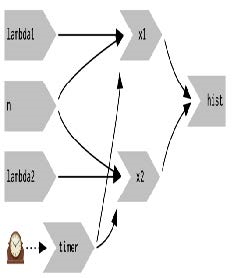

## 5.2 On click

Think about this scenario: if the code took 1 second to run, and we perform simulation every 0.5s, so Shiny would never catch up. Then we might want to require the user to opt-in to **only** performing the expensive calculation by requiring them to click a button. This is a great use case for an `actionButton()`.

```r
ui <- fluidPage(
  fluidRow(
    column(3,
      numericInput("lambda1", label = "lambda1", value = 3),
      numericInput("lambda2", label = "lambda2", value = 5),
      numericInput("n", label = "n", value = 1e4, min = 0),
      actionButton("simulate", "Simulate")
    ),
    column(9, plotOutput("hist"))
  )
)
```

To use the action button we need to learn a new tool. But first, let’s see what if we don’t use the new tool. We will refer to `simulate` without using its value to take a reactive dependency on it:

```r
server <- function(input, output, session) {
  x1 <- reactive({
    input$simulate
    rpois(input$n, input$lambda1)
  })
  x2 <- reactive({
    input$simulate
    rpois(input$n, input$lambda2)
  })

  output$hist <- renderPlot({
    freqpoly(x1(), x2(), binwidth = 1, xlim = c(0, 40))
  })
}
```

We will have the following UI and reactive graph:

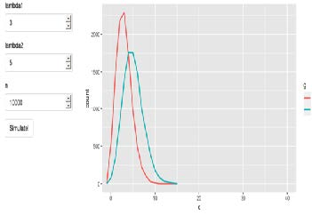

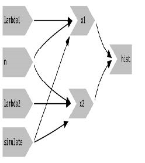

We can see that this only introduces a new dependency, which is `x1()` and `x2()`will update when the simulate button is clicked, but they’ll also continue to update when `lambda1` and `lambda2` or `n` changes. What we want is to **replace** the existing dependencies, but not add to them.

So we need to use a new tool: **a way to use input values without taking a reactive dependency on them**. We need `eventReactive()`, which has two arguments:

- First argument specifies what to take a dependency on.
- Second argument specifies what to compute.

This allows the app to only compute `x1()` and `x2()` when `simulate` is clicked:

```r
server <- function(input, output, session) {
  x1 <- eventReactive(input$simulate, {
    rpois(input$n, input$lambda1)
  })
  x2 <- eventReactive(input$simulate, {
    rpois(input$n, input$lambda2)
  })

  output$hist <- renderPlot({
    freqpoly(x1(), x2(), binwidth = 1, xlim = c(0, 40))
  })
}
```

The new reactive graph will be like this:

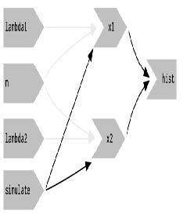

**Note that, `x1` and `x2` no longer have a reactive dependency on `lambda1`, `lambda2`, and `n`: changing their values will not trigger computation. The arrows are greyed-out just to indicate that `x1` and `x2` continue to use the values, but no longer take a reactive dependency on them.**

# 6 Ovservers

So far, we’ve focused on what’s happening inside the app. But sometimes we need to reach outside of the app, for example: saving a file to a shared network drive; sending data to a web API; updating a database; or printing a debugging message to the console. These actions don’t and shouldn’t affect how the app looks, so we shouldn’t use an output and a coupled `render` function. Instead we need to use **observer**.

There are multiple ways to create an observer, which we will come back to them in later a chapter. For now, we will see how to use `observeEvent()`, as it is an important debugging tool when we first learn Shiny.

`observeEvent()` is very similar to `eventReactive()`. Also has two important arguments:

- `eventExpr`, which is the input or expression to take a dependency on.
- `handlerExpr`, which is the code that will be run.

For example, the following modification to `server()` means that every time that `name` is updated, a message will be sent to the console:

```r
ui <- fluidPage(
  textInput("name", "What's your name?"),
  textOutput("greeting")
)

server <- function(input, output, session) {
  string <- reactive(paste0("Hello ", input$name, "!"))
  output$greeting <- renderText(string())
  observeEvent(input$name, {
    message("Greeting performed")
  })
}
```

However, **there are two important differences between `observeEvent()` and `everntReactive()`:**

- **We don’t assign the result of `observeEvent()` to a variable, therefore,**
- **We can’t refer to it from other reactive consumers.**

Oberser and outputs are closely related. So we can draw them the same way in the reactive graph:

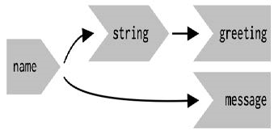